# Reproducible Research Peer Assessment 1

Jennifer Holtzman

January 8, 2017

```r
knitr::opts_chunk$set(echo = TRUE)
```

## Loading and preprocessing the data

- Set the local working directory.
- Load data into a data frame.
- Convert date to a date format from factor.

```r
setwd("C:/Users/Jenny/Documents/COURSERA/5 - Reproducible Research/Week 2")
df <- read.csv("activity.csv")
df$date <- as.POSIXct(df$date, format="%Y-%m-%d")
```

## What is the mean total number of steps taken per day?

For this part of the assignment, you can ignore the missing values in the dataset.

1. Make a histogram of the total number of steps taken each day

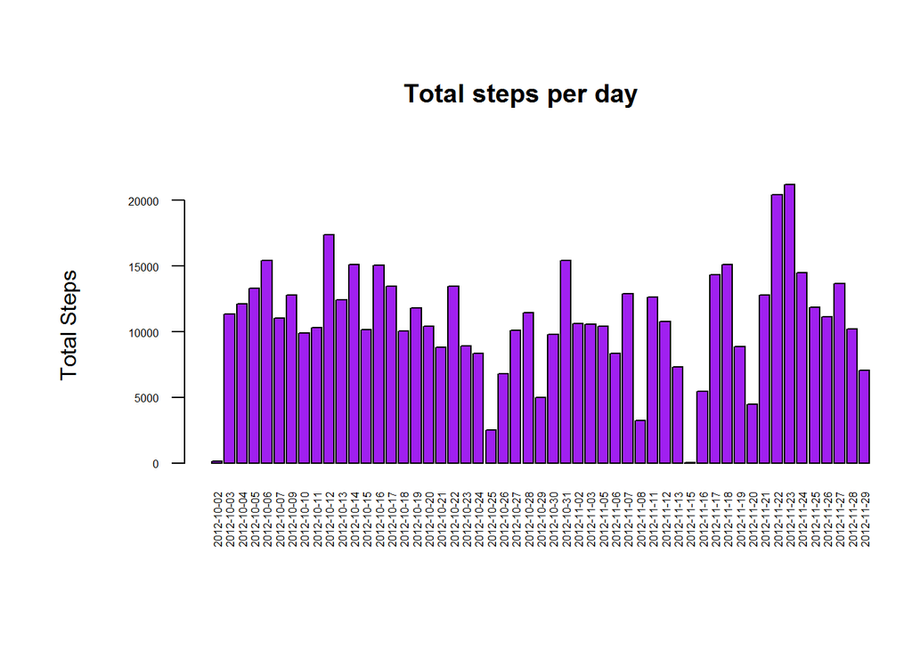

```r
df1 <- na.omit(df)
library(ggplot2)

# Calculate the total steps for each DATE, assign to a list; no NAs
date_total <- tapply(df1$steps, df1$date, sum)

# Histogram of total steps per day; the barplot function will do this
# as histogram shows frequency of total steps, which is not what was asked.
par(mar=c(7,7,7,2)+0.1)
barplot(date_total, las = 2, col = "purple", xlim = c(0, 60), main = "Total steps per day", cex.axis = 0.5, cex.names = 0.5)
mtext("Total Steps", side=2, line=4)
```

```r
png(file = "plot1.png")
par(mar=c(7,7,7,2)+0.1)
barplot(date_total, las = 2, col = "purple", xlim = c(0, 60), main = "Total steps per day", cex.axis = 0.5, cex.names = 0.5)
mtext("Total Steps", side=2, line=4)
dev.off()
```

2. Calculate and report the mean and median total number of steps taken per day

```r
# Calculate the mean / median steps for each DATE, assign to a list; no NAs
date_mean <- tapply(df1$steps, df1$date, mean)
date_med <- tapply(df1$steps, df1$date, median)

# This package needed for changing row names to a new column by reference (setDT, see below)
library(data.table)
# Combine mean and median into a dataframe, print
# Change date to appropriate format
# Rename the columns
steps_stats <- do.call(rbind, mapply(data.frame, mean.steps=date_mean, median.steps=date_med, SIMPLIFY = FALSE))
setDT(steps_stats, keep.rownames = TRUE)
colnames(steps_stats)<- c("date", "mean.steps", "median.steps")
steps_stats$date <- as.POSIXct(steps_stats$date, format="%Y-%m-%d")

# Present a table of the mean and median steps per date
library(xtable)
xt <- xtable(steps_stats)
print(xt, type = "html")
```

|  | date | mean.steps | median.steps |
| --- | --- | --- | --- |
| 1 | 1349150400.00 | 0.44 | 0.00 |
| 2 | 1349236800.00 | 39.42 | 0.00 |
| 3 | 1349323200.00 | 42.07 | 0.00 |
| 4 | 1349409600.00 | 46.16 | 0.00 |
| 5 | 1349496000.00 | 53.54 | 0.00 |
| 6 | 1349582400.00 | 38.25 | 0.00 |
| 7 | 1349755200.00 | 44.48 | 0.00 |
| 8 | 1349841600.00 | 34.38 | 0.00 |
| 9 | 1349928000.00 | 35.78 | 0.00 |
| 10 | 1350014400.00 | 60.35 | 0.00 |
| 11 | 1350100800.00 | 43.15 | 0.00 |
| 12 | 1350187200.00 | 52.42 | 0.00 |
| 13 | 1350273600.00 | 35.20 | 0.00 |
| 14 | 1350360000.00 | 52.38 | 0.00 |
| 15 | 1350446400.00 | 46.71 | 0.00 |
| 16 | 1350532800.00 | 34.92 | 0.00 |
| 17 | 1350619200.00 | 41.07 | 0.00 |
| 18 | 1350705600.00 | 36.09 | 0.00 |
| 19 | 1350792000.00 | 30.63 | 0.00 |
| 20 | 1350878400.00 | 46.74 | 0.00 |
| 21 | 1350964800.00 | 30.97 | 0.00 |
| 22 | 1351051200.00 | 29.01 | 0.00 |
| 23 | 1351137600.00 | 8.65 | 0.00 |
| 24 | 1351224000.00 | 23.53 | 0.00 |
| 25 | 1351310400.00 | 35.14 | 0.00 |
| 26 | 1351396800.00 | 39.78 | 0.00 |
| 27 | 1351483200.00 | 17.42 | 0.00 |
| 28 | 1351569600.00 | 34.09 | 0.00 |
| 29 | 1351656000.00 | 53.52 | 0.00 |
| 30 | 1351828800.00 | 36.81 | 0.00 |
| 31 | 1351915200.00 | 36.70 | 0.00 |
| 32 | 1352091600.00 | 36.25 | 0.00 |
| 33 | 1352178000.00 | 28.94 | 0.00 |
| 34 | 1352264400.00 | 44.73 | 0.00 |
| 35 | 1352350800.00 | 11.18 | 0.00 |
| 36 | 1352610000.00 | 43.78 | 0.00 |
| 37 | 1352696400.00 | 37.38 | 0.00 |
| 38 | 1352782800.00 | 25.47 | 0.00 |
| 39 | 1352955600.00 | 0.14 | 0.00 |
| 40 | 1353042000.00 | 18.89 | 0.00 |
| 41 | 1353128400.00 | 49.79 | 0.00 |
| 42 | 1353214800.00 | 52.47 | 0.00 |
| 43 | 1353301200.00 | 30.70 | 0.00 |
| 44 | 1353387600.00 | 15.53 | 0.00 |
| 45 | 1353474000.00 | 44.40 | 0.00 |
| 46 | 1353560400.00 | 70.93 | 0.00 |
| 47 | 1353646800.00 | 73.59 | 0.00 |
| 48 | 1353733200.00 | 50.27 | 0.00 |
| 49 | 1353819600.00 | 41.09 | 0.00 |
| 50 | 1353906000.00 | 38.76 | 0.00 |
| 51 | 1353992400.00 | 47.38 | 0.00 |
| 52 | 1354078800.00 | 35.36 | 0.00 |
| 53 | 1354165200.00 | 24.47 | 0.00 |

## What is the average daily activity pattern?

1. Make a time series plot (i.e. type = “l”) of the 5-minute interval (x-axis) and the average number of steps taken, averaged across all days (y-axis)
2. Which 5-minute interval, on average across all the days in the dataset, contains the maximum number of steps?

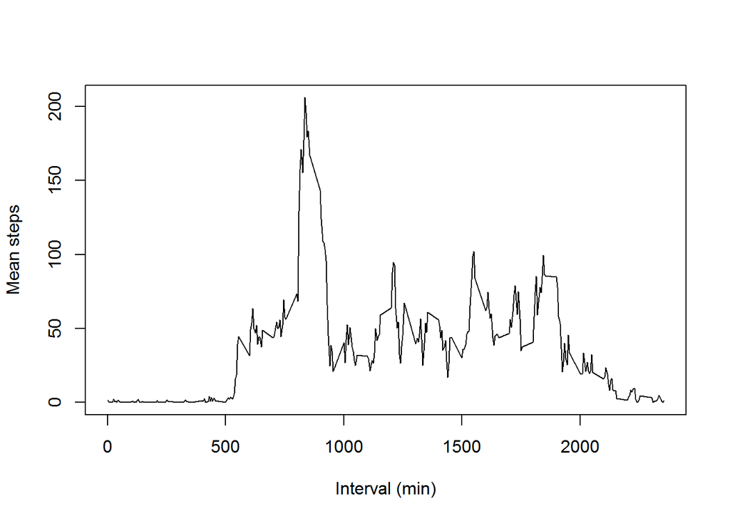

```r
int_mean <- tapply(df1$steps, df1$interval, mean)
int_names <-row.names(int_mean)
int_names <- as.numeric(as.character(int_names))
int_df <- data.frame(int_names, int_mean)
plot(int_df$int_names, int_df$int_mean, type = "l", xlab = "Interval (min)", ylab = "Mean steps")
```

```r
step_max <- max(int_df$int_mean)
row_max <- which(grepl(step_max, int_df$int_mean))
int_max <- int_df$int_names[row_max]

png(file = "plot2.png")
plot2 <- plot(int_df$int_names, int_df$int_mean, type = "l", xlab = "Interval (min)", ylab = "Mean steps")
dev.off()
```

Answer: The maximum number of steps, 206.1698113, occurs at interval beginning at 835 minutes.

## Imputing missing values

Note that there are a number of days/intervals where there are missing values (coded as NA). The presence of missing days may introduce bias into some calculations or summaries of the data.

1. Calculate and report the total number of missing values in the dataset (i.e. the total number of rows with NAs)

```r
# Count the NAs
NA_count <- sum(is.na(df$steps))
```

Answer: The number of missing values is 2304.

2. Devise a strategy for filling in all of the missing values in the dataset. The strategy does not need to be sophisticated. For example, you could use the mean/median for that day, or the mean for that 5-minute interval, etc.
3. Create a new dataset that is equal to the original dataset but with the missing data filled in.

```r
# This package needed for changing row names to a new column by reference (setDT, see below)
library(data.table)

# Calculate the mean steps for each INTERVAL, assign to a list; no NAs
interval_mean <- tapply(df1$steps, df1$interval, mean)

# Convert the list of interval-means to a data frame, with the intervals as a separate column
# Rename the columns
interval_df <- data.frame(interval_mean)
setDT(interval_df, keep.rownames = TRUE)
colnames(interval_df)<- c("interval", "mean.steps")

# Copy original df to a new variable, contains all NAs
df2 <- df

# Loop to replace NAs with imputed values in the copied dataset, df2.
# There are 17546 entries. Intervals are numbered 1 to 288 and repeat 61 times (288*61=17546).
# If na is found at (line_count)th step, replace NA with the mean for that time interval
line_count <- 0
for(j in 1:61){
  for(k in 1:288){
    line_count <- line_count + 1
    this_int <- interval_df$interval[[k]]
      if(is.na(df2$steps[line_count])){
        df2$steps[line_count] <- interval_df$mean.steps[which(interval_df$interval == this_int)]
      }
  }
}
```

4a. Make a histogram of the total number of steps taken each day [using the data set using imputed NAs].

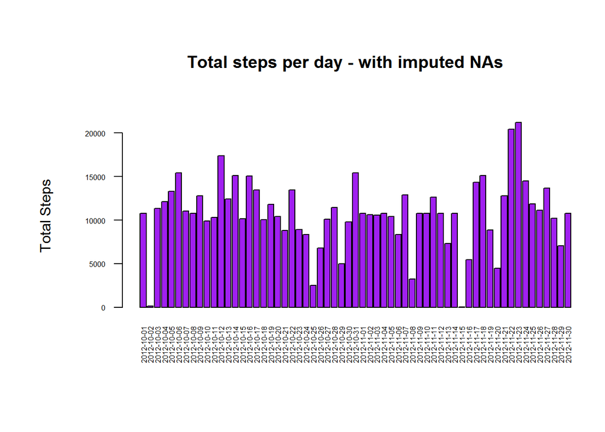

```r
# Calculate the total / median / mean steps for each DATE, assign to a list; use df2 containing imputed NAs
date_total2 <- tapply(df2$steps, df2$date, sum)
date_mean2 <- tapply(df2$steps, df2$date, mean)
date_med2 <- tapply(df2$steps, df2$date, median)

# Histogram of total steps per day; the barplot function will do this
# as histogram shows frequency of total steps, which is not what was asked.
par(mar=c(7,7,7,2)+0.1)
barplot(date_total2, las = 2, col = "purple", xlim = c(0, 70), main = "Total steps per day - with imputed NAs", cex.axis = 0.5, cex.names = 0.5)
mtext("Total Steps", side=2, line=4)
```

```r
# Print to png device
png(file="plot3.png",width=600,height=350,res=45)
par(mar=c(7,7,7,2)+0.1)
barplot(date_total2, las = 2, col = "purple", xlim = c(0, 70), main = "Total steps per day - with imputed NAs", cex.axis = 0.5, cex.names = 0.5)
mtext("Total Steps", side=2, line=4)
dev.off()
```

4b. Calculate and report the mean and median total number of steps taken per day. Do these values differ from the estimates from the first part of the assignment? What is the impact of imputing missing data on the estimates of the total daily number of steps?

```r
# Combine mean and median into a dataframe
# Change date to appropriate format
# Rename the columns
steps_stats2 <- do.call(rbind, mapply(data.frame, mean.steps=date_mean2, median.steps=date_med2, SIMPLIFY = FALSE))
setDT(steps_stats2, keep.rownames = TRUE)
colnames(steps_stats2)<- c("date", "mean.steps", "median.steps")
steps_stats2$date <- as.POSIXct(steps_stats2$date, format="%Y-%m-%d")

# Present a table of the mean and median steps per date
library(xtable)
xt2 <- xtable(steps_stats2)
print(xt2, type = "html")
```

|  | date | mean.steps | median.steps |
| --- | --- | --- | --- |
| 1 | 1349064000.00 | 37.38 | 34.11 |
| 2 | 1349150400.00 | 0.44 | 0.00 |
| 3 | 1349236800.00 | 39.42 | 0.00 |
| 4 | 1349323200.00 | 42.07 | 0.00 |
| 5 | 1349409600.00 | 46.16 | 0.00 |
| 6 | 1349496000.00 | 53.54 | 0.00 |
| 7 | 1349582400.00 | 38.25 | 0.00 |
| 8 | 1349668800.00 | 37.38 | 34.11 |
| 9 | 1349755200.00 | 44.48 | 0.00 |
| 10 | 1349841600.00 | 34.38 | 0.00 |
| 11 | 1349928000.00 | 35.78 | 0.00 |
| 12 | 1350014400.00 | 60.35 | 0.00 |
| 13 | 1350100800.00 | 43.15 | 0.00 |
| 14 | 1350187200.00 | 52.42 | 0.00 |
| 15 | 1350273600.00 | 35.20 | 0.00 |
| 16 | 1350360000.00 | 52.38 | 0.00 |
| 17 | 1350446400.00 | 46.71 | 0.00 |
| 18 | 1350532800.00 | 34.92 | 0.00 |
| 19 | 1350619200.00 | 41.07 | 0.00 |
| 20 | 1350705600.00 | 36.09 | 0.00 |
| 21 | 1350792000.00 | 30.63 | 0.00 |
| 22 | 1350878400.00 | 46.74 | 0.00 |
| 23 | 1350964800.00 | 30.97 | 0.00 |
| 24 | 1351051200.00 | 29.01 | 0.00 |
| 25 | 1351137600.00 | 8.65 | 0.00 |
| 26 | 1351224000.00 | 23.53 | 0.00 |
| 27 | 1351310400.00 | 35.14 | 0.00 |
| 28 | 1351396800.00 | 39.78 | 0.00 |
| 29 | 1351483200.00 | 17.42 | 0.00 |
| 30 | 1351569600.00 | 34.09 | 0.00 |
| 31 | 1351656000.00 | 53.52 | 0.00 |
| 32 | 1351742400.00 | 37.38 | 34.11 |
| 33 | 1351828800.00 | 36.81 | 0.00 |
| 34 | 1351915200.00 | 36.70 | 0.00 |
| 35 | 1352001600.00 | 37.38 | 34.11 |
| 36 | 1352091600.00 | 36.25 | 0.00 |
| 37 | 1352178000.00 | 28.94 | 0.00 |
| 38 | 1352264400.00 | 44.73 | 0.00 |
| 39 | 1352350800.00 | 11.18 | 0.00 |
| 40 | 1352437200.00 | 37.38 | 34.11 |
| 41 | 1352523600.00 | 37.38 | 34.11 |
| 42 | 1352610000.00 | 43.78 | 0.00 |
| 43 | 1352696400.00 | 37.38 | 0.00 |
| 44 | 1352782800.00 | 25.47 | 0.00 |
| 45 | 1352869200.00 | 37.38 | 34.11 |
| 46 | 1352955600.00 | 0.14 | 0.00 |
| 47 | 1353042000.00 | 18.89 | 0.00 |
| 48 | 1353128400.00 | 49.79 | 0.00 |
| 49 | 1353214800.00 | 52.47 | 0.00 |
| 50 | 1353301200.00 | 30.70 | 0.00 |
| 51 | 1353387600.00 | 15.53 | 0.00 |
| 52 | 1353474000.00 | 44.40 | 0.00 |
| 53 | 1353560400.00 | 70.93 | 0.00 |
| 54 | 1353646800.00 | 73.59 | 0.00 |
| 55 | 1353733200.00 | 50.27 | 0.00 |
| 56 | 1353819600.00 | 41.09 | 0.00 |
| 57 | 1353906000.00 | 38.76 | 0.00 |
| 58 | 1353992400.00 | 47.38 | 0.00 |
| 59 | 1354078800.00 | 35.36 | 0.00 |
| 60 | 1354165200.00 | 24.47 | 0.00 |
| 61 | 1354251600.00 | 37.38 | 34.11 |

```r
# Present tables summarizing the data with and without imputed NA values
xt3 <- xtable(summary(steps_stats), caption = "No imputed NAs")
print(xt3, type = "html", include.rownames = FALSE, include.colnames = FALSE)
```

No imputed NAs

| Min. :2012-10-02 00:00:00 | Min. : 0.1424 | Min. :0 |
| --- | --- | --- |
| 1st Qu.:2012-10-16 00:00:00 | 1st Qu.:30.6979 | 1st Qu.:0 |
| Median :2012-10-29 00:00:00 | Median :37.3785 | Median :0 |
| Mean :2012-10-30 17:37:21 | Mean :37.3826 | Mean :0 |
| 3rd Qu.:2012-11-16 00:00:00 | 3rd Qu.:46.1597 | 3rd Qu.:0 |
| Max. :2012-11-29 00:00:00 | Max. :73.5903 | Max. :0 |

```r
xt4 <- xtable(summary(steps_stats2), caption = "With imputed NAs")
print(xt4, type = "html", include.rownames = FALSE, include.colnames = FALSE)
```

With imputed NAs

| Min. :2012-10-01 00:00:00 | Min. : 0.1424 | Min. : 0.000 |
| --- | --- | --- |
| 1st Qu.:2012-10-16 00:00:00 | 1st Qu.:34.0938 | 1st Qu.: 0.000 |
| Median :2012-10-31 00:00:00 | Median :37.3826 | Median : 0.000 |
| Mean :2012-10-31 00:25:34 | Mean :37.3826 | Mean : 4.474 |
| 3rd Qu.:2012-11-15 00:00:00 | 3rd Qu.:44.4826 | 3rd Qu.: 0.000 |
| Max. :2012-11-30 00:00:00 | Max. :73.5903 | Max. :34.113 |

```r
# Calculate overall sum of steps without and with imputed NA values
total1 <- sum(date_total)
total2 <- sum(date_total2)
```

Answer: Differences between data not containing and containing imputed NA values include (1) imputing filled in data for days that were missing; (2) maximum and minimum values are the same for both; (3) global mean is the same for both; and (4) global median is slightly higher with imputed NAs (37.3826) vs without (37.3785).

The global total steps without imputed NA values is 570608, and it is 6.567375110^{5} with imputed NAs. From this and from inspection of the graph of total steps, imputing missing data increased the estimated total daily number of steps.

## Are there differences in activity patterns between weekdays and weekends?

1. Create a new factor variable in the dataset with two levels – “weekday” and “weekend” indicating whether a given date is a weekday or weekend day.
2. Make a panel plot containing a time series plot (i.e. type = “l”) of the 5-minute interval (x-axis) and the average number of steps taken, averaged across all weekday days or weekend days (y-axis).

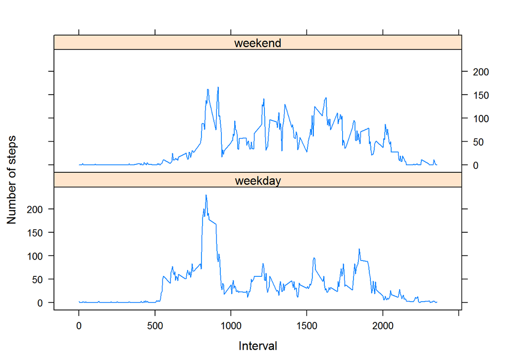

It appears as though activity begins later in the day on weekends compared to weekends.